# Analyzing COVID-19 Stimulus Checks and their Impact on Consumer Price Index

# EXPLORATORY DATA ANALYSIS (EDA)

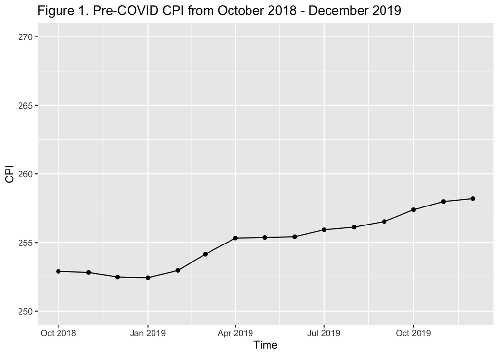

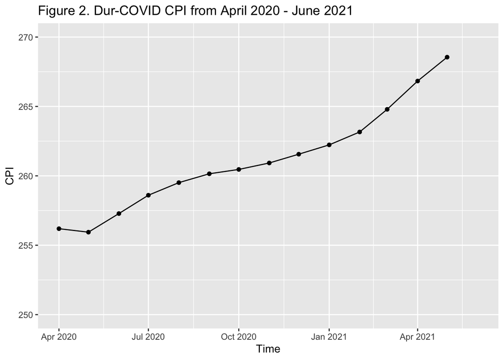

This exploratory data analysis answers the first research question that we conclude that the CPI changes more over the COVID-19 pandemic period compared to 15 month ahead of it. Further statistical analysis about the association will be conducted below.

Next, the data that we have lists all of the values for the CPI and the total amount of Stimulus checks in chronological order, starting at April 2020 to June 2021 by the regions. This gives us a hint that we want to look at the CPI and Stimulus check totals by region. We first want to plot the time series for the CPI by the regions of the Untied States.

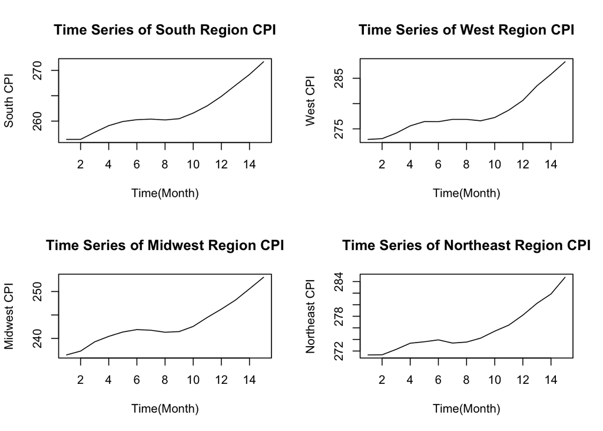

**Figure 3. Times Series for CPI by regions of the U.S.**

This gives us a detailed look at what the CPI looks like at each region. From here, we can see that each of the region’s CPI are non-stationary. Stationarity means that there is a constant mean over the given time period of our data and a variance that does not depend on the time. Since our data is not stationary, we need to transform our data in order to make it stationary. Once our data is stationary, we are able to then make inferences about our data.

In order to make our data stationary, we use time series regression. This process removes the nonstationarity from our model, which in turn will allow us to use these results to answer our questions.

# STATISTICAL ANALYSIS

In order to use regression to manipulate our data, we must first find out which of the time series models best fits our data. This is done by simulating ARMA(p,q) models with our data as a basis and looking at the results of the output. The coefficient(s) that are given will then be used to create the regression model that will be our final results.

Checking all possible ARMA(p,q) models, we found out that the ARMA(1,0) (also called AR(1)) model to provide the most beneficial results.

Next, we will create the regression model for our data using the AR(1) coefficient we found and the data that we are given. Below is the process of doing said regression model.

From this output, we can see that there is a significant relationship between the CPI and Stimulus checks by the regions of the United States using a 95% confidence level. The p-value for the Stimulus checks is 0.00958. The p-value for each of the regions is a very small value. Next, we want to see if the regression assumptions for our model are checked.

We can see from our regression output that the assumptions are met. The only concern is for the data point 30 in our data which has a high Cook’s distance, however, it is the only point within our data with that high of a Cook’s distance. We also do not want to remove said data point since we’re working with limited data.

Next, we will take a look at the Autocorrelation Function (ACF) and Partial-Autocorrelation Function (PACF) for the residuals of our model.

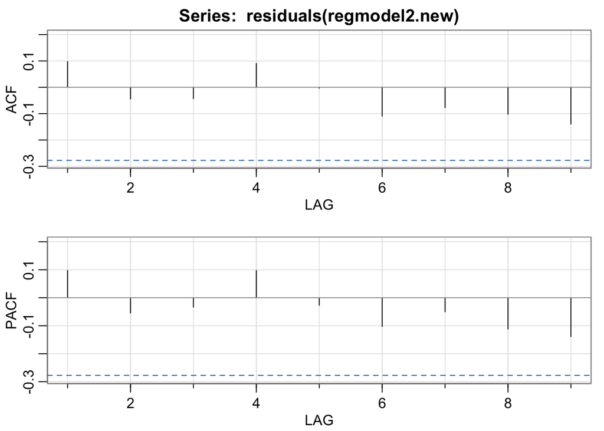

```
##      [,1]  [,2]  [,3] [,4]  [,5]  [,6]  [,7]  [,8]  [,9]
## ACF   0.1 -0.04 -0.04 0.09  0.00 -0.11 -0.08 -0.10 -0.14
## PACF  0.1 -0.05 -0.03 0.10 -0.03 -0.10 -0.05 -0.11 -0.14
```

**Figure 5. ACF and PACF of the regression**

Looking at Figure 5, we can see that there is no autocorrelation within the model that we created. This means that none of the data points influence the outcome or results of data points before or after it. In conclusion, we have a regression model that fits all assumptions.

# RECOMMENDATIONS

This project intends to answer two main research question:

- Does CPI change more over the COVID-19 pandemic period than it’s previous years?
- Does the issuance of Economic Relief Payments over the COVID-19 pandemic period have a significant impact on the price of goods?

According to the conducted times series analysis, we show that there is a significant relationship between the CPI during the COVID-19 pandemic and the COVID Stimulus checks and the regions of the United States. When factoring the regions in the model, we see that the Stimulus checks has a significant effect to United States CPI. Therefore, there is a relationship between the COVID-19 Economic Payments and the increase of price of goods.

# CONSIDERATIONS

Although this project has showed that there is a significant relationship between the issuance of COVID-19 pandemic relief payments and the price of goods over this period, distributing the money by the government may not be the only reason that drives the price of goods to go up. Considering the economic concepts behind this, price of goods goes up may simply be the reason of the high demand or shortage of a certain product.

Additionally, this study assumes that people would spend all of the payments that they get within each rounds of payments, and we expect the monetary effect reflects in the CPI in the month that person spends.We all know it’s never the case in real world. We suspect there are other factors that contribute the increase of CPI over the COVID-19 pandemic period, and further complicated methods could be used to extend this study.

*We would like to give a special “thank you” to Dr.Conor B Ryan, who is an Assistant Professor in the Department of Economics at Penn State, for the help and support to this project.*

# RESOURCES

The following are sources used to complete this projects:

Economic impact payments. Internal Revenue Service. (n.d.). Retrieved December 7, 2021, from https://www.irs.gov/coronavirus/economic-impact-payments.

Consumer price index for all urban consumers: All items in U.S. city average. FRED. (2021, November 10). Retrieved December 7, 2021, from https://fred.stlouisfed.org/series/CPIAUCSL.

# TECHNICAL APPENDIX

## Assumptions Checked for Time Series Model

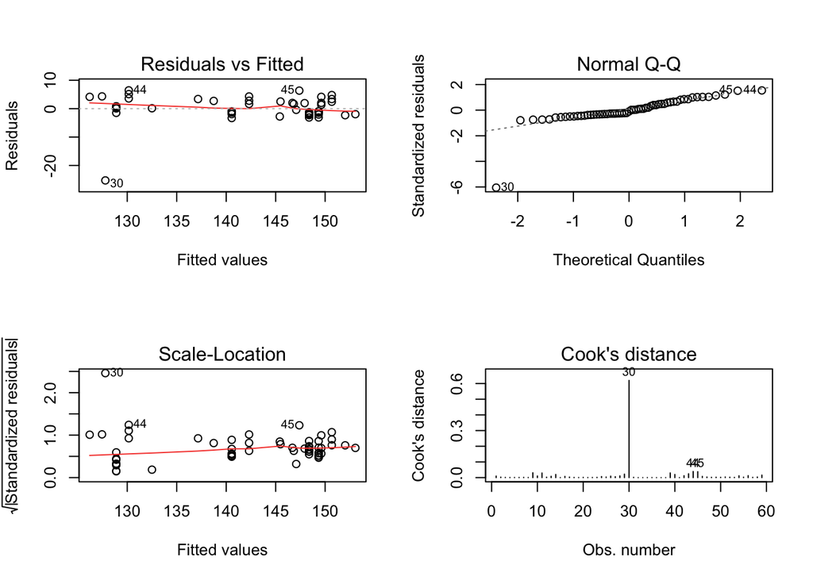

**Figure 4. Checking Assumptions**

## Results of ARMA(p,q) Model

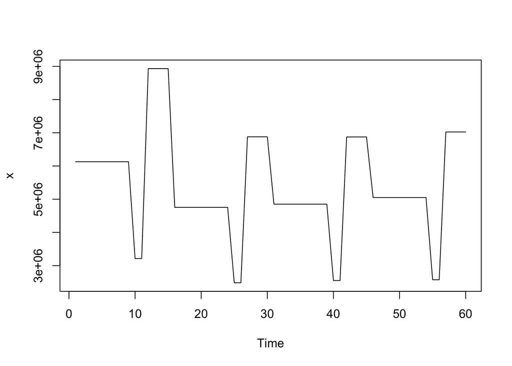

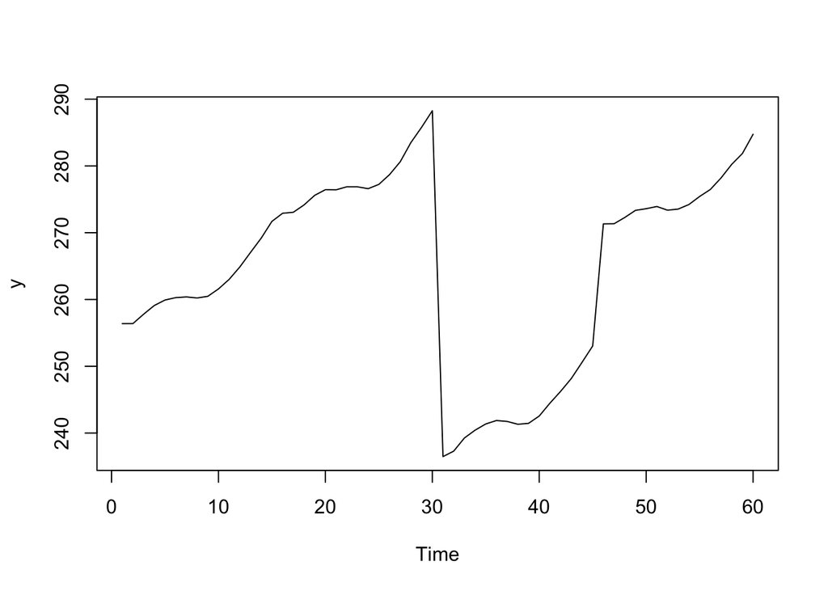

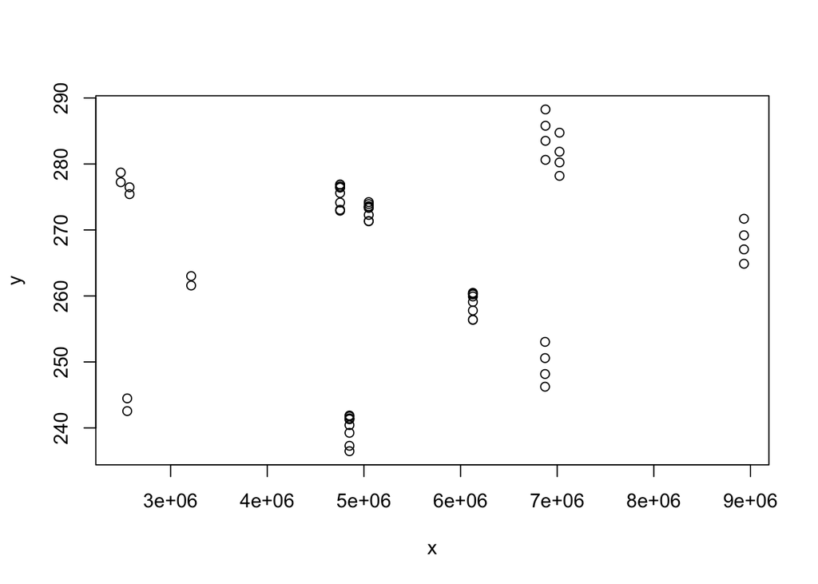

```
##
## Call:
## lm(formula = y ~ x + Master$Region, data = Master)
##
## Residuals:
##    Min     1Q Median     3Q    Max
## -6.214 -1.973 -1.018  3.167  6.911
##
## Coefficients:
##                         Estimate Std. Error t value Pr(>|t|)
## (Intercept)            2.344e+02  1.889e+00 124.140  < 2e-16 ***
## x                      1.701e-06  3.223e-07   5.277 2.29e-06 ***
## Master$RegionNortheast 3.223e+01  1.329e+00  24.255  < 2e-16 ***
## Master$RegionSouth     1.642e+01  1.403e+00  11.706  < 2e-16 ***
## Master$RegionWest      3.523e+01  1.328e+00  26.531  < 2e-16 ***
## ---
## Signif. codes:  0 '***' 0.001 '**' 0.01 '*' 0.05 '.' 0.1 ' ' 1
##
## Residual standard error: 3.636 on 55 degrees of freedom
## Multiple R-squared:  0.9429, Adjusted R-squared:  0.9388
## F-statistic: 227.1 on 4 and 55 DF,  p-value: < 2.2e-16
```

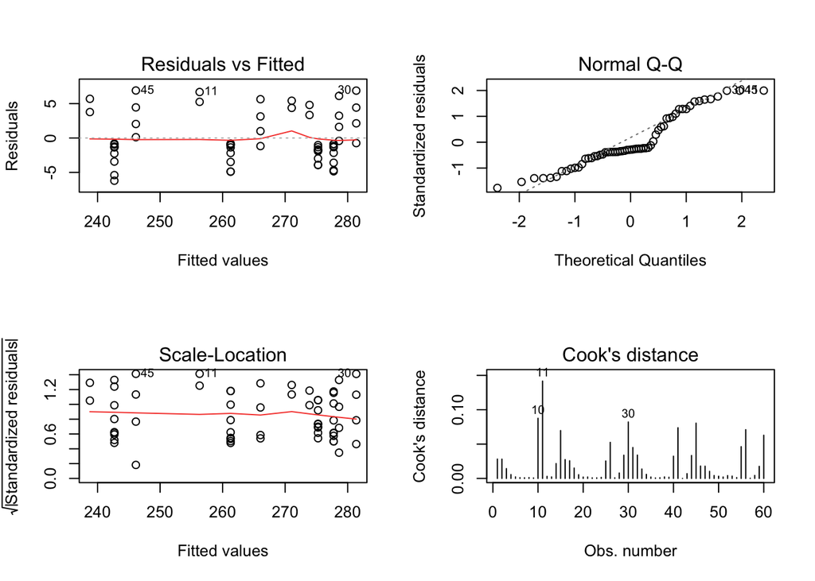

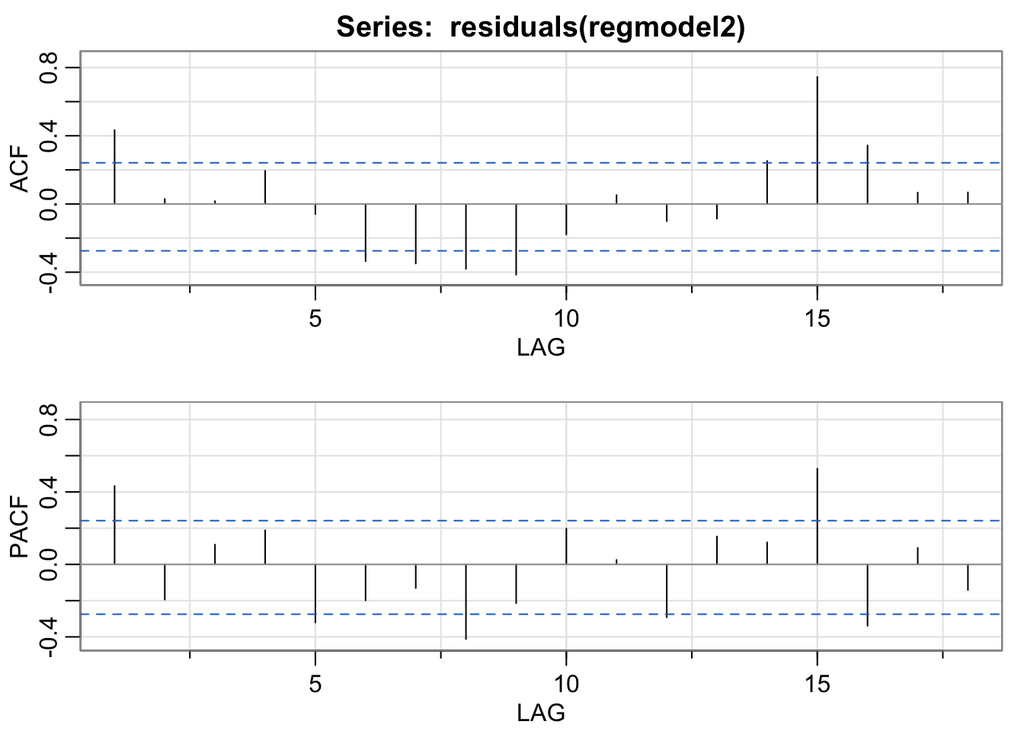

```
##      [,1]  [,2] [,3] [,4]  [,5]  [,6]  [,7]  [,8]  [,9] [,10] [,11] [,12] [,13]
## ACF  0.43  0.03 0.02 0.19 -0.06 -0.34 -0.35 -0.38 -0.41 -0.18  0.05 -0.10 -0.09
## PACF 0.43 -0.19 0.11 0.19 -0.32 -0.20 -0.13 -0.41 -0.21  0.20  0.02 -0.29  0.15
##      [,14] [,15] [,16] [,17] [,18]
## ACF   0.25  0.75  0.34  0.07  0.07
## PACF  0.12  0.53 -0.34  0.09 -0.14
```

```
##
## Call:
## arima(x = residuals(regmodel2), order = c(1, 0, 0), include.mean = F)
##
## Coefficients:
##          ar1
##       0.4647
## s.e.  0.1186
##
## sigma^2 estimated as 9.636:  log likelihood = -153.22,  aic = 308.45
```

## Regression Model Output

```
## (Intercept)
##    235.1106
```

```
##
## Call:
## lm(formula = y.new ~ x.new + Master$Region[-1])
##
## Residuals:
##      Min       1Q   Median       3Q      Max
## -25.2678  -1.5233  -0.4215   2.2237   6.4449
##
## Coefficients:
##                             Estimate Std. Error t value Pr(>|t|)
## (Intercept)                1.259e+02  1.631e+00  77.161  < 2e-16 ***
## x.new                      1.168e-06  4.347e-07   2.686  0.00958 **
## Master$Region[-1]Northeast 1.937e+01  1.589e+00  12.190  < 2e-16 ***
## Master$Region[-1]South     1.088e+01  1.659e+00   6.556 2.17e-08 ***
## Master$Region[-1]West      2.052e+01  1.589e+00  12.914  < 2e-16 ***
## ---
## Signif. codes:  0 '***' 0.001 '**' 0.01 '*' 0.05 '.' 0.1 ' ' 1
##
## Residual standard error: 4.35 on 54 degrees of freedom
## Multiple R-squared:  0.8021, Adjusted R-squared:  0.7874
## F-statistic: 54.71 on 4 and 54 DF,  p-value: < 2.2e-16
```

## R code

```r
# clean up & set default chunk options
rm(list = ls())
knitr::opts_chunk$set(echo = FALSE)

# packages
library(data.table)
library(readr)
library(knitr)
library(dplyr)
library(ggplot2)
library(kableExtra)
library(lubridate)

# inputs
Payment <- read.csv("Pmt_detail.csv")
setnames(Payment, c("Names", "Date", "Payment Amount"))

Variables <- read.csv("Variables_Table.csv")
setnames(Variables, c("Variables", "Description", "Type", "Comments"))

Diff <- read.csv("CPI_Diff.csv")
setnames(Diff, c("Period", "Averaged Monthly Change in CPI "))

AR_Results <- read.csv("ARMA_Results.csv")
#setnames(AR_Results, c(""))
Master <- fread("./Master.csv")
plot.ts(Master$CPI, main="Time Series of CPI")

South_Final <- fread("./South_Final.csv")
West_Final <- fread("./West_Final.csv")
Midwest_Final <- fread("./Midwest_Final.csv")
Northeast_Final <- fread("./Northeast_Final.csv")
par(mfrow=c(2,2))
plot.ts(South_Final$CPI, main="Time Series of South Region CPI", xlab = "Time(Month)", ylab = "South CPI")
plot.ts(West_Final$CPI, main="Time Series of West Region CPI", xlab = "Time(Month)", ylab = "West CPI")
plot.ts(Midwest_Final$CPI, main="Time Series of Midwest Region CPI", xlab = "Time(Month)", ylab = "Midwest CPI")
plot.ts(Northeast_Final$CPI, main="Time Series of Northeast Region CPI", xlab = "Time(Month)", ylab = "Northeast CPI")
## look at the residuals
## assumptions
par(mfrow=c(2,2))
plot(regmodel2.new,which=1:4)
require(TSA)
require(astsa)
## read in the data
x=ts(Master$Stimulus)

y=ts(Master$CPI)
y.new<-y[-1]-0.4647*y[-length(y)]

## new xt
x.new<-x[-1]-0.4647*x[-length(x)]
## acf and pacf

regmodel2.new <- lm(y.new ~ x.new + Master$Region[-1])
acf2(residuals(regmodel2.new))
```